# Lista de Exercícios 2

Entrega: **07/05/2022** via Moodle (até as 23:59)

⚠️Você irá entregar essa lista de exercício no Moodle da disciplina. Você deverá submeter o **arquivo gerado automaticamente pelo R** usando *markdown*, preferencialmente o pdf. Para isso, siga as instruções abaixo para instalar os demais programas e pacotes.

Caso você tenha dificuldades nesse processo, você pode me enviar uma mensagem pelo Moodle com informações sobre os erros encontrados para que eu possa te ajudar.

## Instruções

- Tenha certeza que as suas versões do R e RStudio estão atualizadas, e que você instalou os pacotes `markdown` e `rmarkdown`.
- Para gerar automaticamente o seu relatório em pdf, você vai precisar instalar o programa MikTek (versão completa): https://miktex.org/download. Clique na aba “All downloads” e selecione “Net Installer”. Depois de fazer o download, você deve **instalar** o programa no seu computador. Durante a instalação, se pedir para selecionar o tamanho do papel, escolha o tamanho A4. **Cuidado**, este processo pode ser demorado.
- Uma outra opção é instalar o pacote `tinytex` diretamente no R (com o comando `install.packages("tinytex")`). Depois, execute o comando `tinytex::install_tinytex()` para instalar uma versão local do LaTeX. **Importante:** para usar essa opção, você não pode ter o MikTex instalado.

  Reinicie o RStudio e você já deverá conseguir gerar o pdf com a opção **Knit to PDF**. Pode ser que apareça alguma mensagem de erro, mas é possível ignorá-la e gerar o pdf mesmo assim.
- Antes de começar os exercícios, salve o *template* lista-01.Rmd na sua pasta de trabalho com o nome apropriado. Se os acentos não estiverem aparecendo corretamente, antes de editar o arquivo, selecione o menu **File**, a opção **Reopen with Encoding** e selecione `UTF-8`.
- Ao abrir o *template* no RStudio, ele deverá reconhecer automaticamente o formato .Rmd do arquivo. Ao clicar no botão **Knit**, selecione a opção **Knit to PDF**. O R irá executar o comando, e irá criar o relatório em pdf no mesmo diretório que está o seu arquivo que deverá aparecer assim:

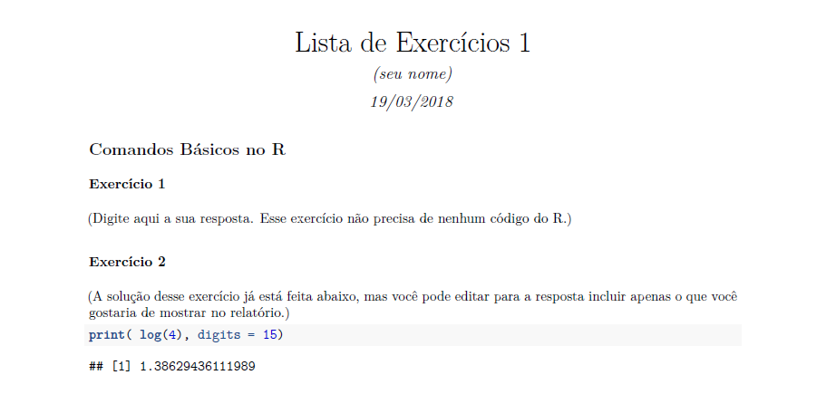

## Dicas

- Lembre-se que você pode controlar como o R irá incluir os *chunks* de código com as opções `eval`, `echo`, `results` entre outras. Veja as principais opções no [cheatsheet](https://www.rstudio.com/wp-content/uploads/2015/02/rmarkdown-cheatsheet.pdf), ou então mais detalhes no link https://rmarkdown.rstudio.com/lesson-3.html.

## Funções no R

1. Escreva uma função `seqrep(n)` que retorne o vetor `(1; 2; 2; 3; 3; 3; : : : ; n)` onde cada inteiro $k$ é repetido $k$ vezes. Qual é o tamanho desse vetor para `n=50`? (Não imprima o vetor todo, informe apenas o seu tamanho.)
2. Dado um vetor `x`, escreva uma função que retorne apenas os elementos de `x` que forem maiores do que a média de `x`.
3. Aplique a função do Exercício 2 ao vetor gerado pela função `seqrep(n)` acima para `n=10`, e imprima o resultado.
4. Calcule o resultado da expressão:
   $$\sum_{i=10}^{20} (i^2 + 4/i)$$
5. Calcule o resultado da expressão:
   $$\sum_{i=1}^{10} \sum_{j=1}^{10} \frac{i^2}{(5+i*j)}$$
6. Dado `a = c(-0.2,0.2,0.49,0.5,0.51,.99,1.2)`, qual é a diferença entre as funções `trunc(a)`, `floor(a)`, `ceiling(a)` e `round(a)`?
7. Dado um vetor `x`, use a função `ifelse()` para gerar um vetor de mesmo tamanho de `x` com o logaritmo dos números que forem positivos, e `NA` quando os elementos forem negativos. Aplique esta função ao vetor gerado pelos comandos abaixo:

```r
set.seed(1)
x = runif(20,-1,1)
```

8. Crie um vetor de tamanho 100, onde os elementos sejam strings da forma “Seg1”, “Seg2”, …, “Seg100”.

## Base de Dados

9. Encontre o banco de dados `accident` do pacote `hmmm`. Quantas linhas tem o banco de dados? E quantos acidentes no total foram registrados? Inclua os comandos que você utilizou para encontrar as respostas.
10. Qual é a média da variável `Freq` para os acidentes do tipo `uncertain`? Considerando os acidentes do tipo `avoidable`, encontre os valores das demais variáveis (tempo afastado, faixa etária e período do dia) em que houve mais acidentes.

## Resolução

Sugestão de respostas:

- Resolução Lista 2
- Arquivo .Rmd